# Risk Factor Analysis

## Outcome Variable

**Outcome Variable:** ever_stunted

## Predictor Variables

**Intervention Variable:** parity

**Adjustment Set:**

unadjusted

## Stratifying Variables

The analysis was stratified on these variable(s):

- agecat
- studyid
- country

## Data Summary

| agecat | studyid | country | parity | ever_stunted | n_cell | n |
| --- | --- | --- | --- | --- | --- | --- |
| 0-6 months | ki1000304b-SAS-CompFeed | INDIA | 1 | 0 | 289 | 1530 |
| 0-6 months | ki1000304b-SAS-CompFeed | INDIA | 1 | 1 | 162 | 1530 |
| 0-6 months | ki1000304b-SAS-CompFeed | INDIA | 2 | 0 | 266 | 1530 |
| 0-6 months | ki1000304b-SAS-CompFeed | INDIA | 2 | 1 | 93 | 1530 |
| 0-6 months | ki1000304b-SAS-CompFeed | INDIA | 3+ | 0 | 534 | 1530 |
| 0-6 months | ki1000304b-SAS-CompFeed | INDIA | 3+ | 1 | 186 | 1530 |
| 0-6 months | ki1000304b-SAS-FoodSuppl | INDIA | 1 | 0 | 46 | 396 |
| 0-6 months | ki1000304b-SAS-FoodSuppl | INDIA | 1 | 1 | 31 | 396 |
| 0-6 months | ki1000304b-SAS-FoodSuppl | INDIA | 2 | 0 | 58 | 396 |
| 0-6 months | ki1000304b-SAS-FoodSuppl | INDIA | 2 | 1 | 33 | 396 |
| 0-6 months | ki1000304b-SAS-FoodSuppl | INDIA | 3+ | 0 | 139 | 396 |
| 0-6 months | ki1000304b-SAS-FoodSuppl | INDIA | 3+ | 1 | 89 | 396 |
| 0-6 months | ki1017093b-PROVIDE | BANGLADESH | 1 | 0 | 245 | 700 |
| 0-6 months | ki1017093b-PROVIDE | BANGLADESH | 1 | 1 | 26 | 700 |
| 0-6 months | ki1017093b-PROVIDE | BANGLADESH | 2 | 0 | 218 | 700 |
| 0-6 months | ki1017093b-PROVIDE | BANGLADESH | 2 | 1 | 26 | 700 |
| 0-6 months | ki1017093b-PROVIDE | BANGLADESH | 3+ | 0 | 171 | 700 |
| 0-6 months | ki1017093b-PROVIDE | BANGLADESH | 3+ | 1 | 14 | 700 |
| 0-6 months | ki1066203-TanzaniaChild2 | TANZANIA, UNITED REPUBLIC OF | 1 | 0 | 775 | 2363 |
| 0-6 months | ki1066203-TanzaniaChild2 | TANZANIA, UNITED REPUBLIC OF | 1 | 1 | 67 | 2363 |
| 0-6 months | ki1066203-TanzaniaChild2 | TANZANIA, UNITED REPUBLIC OF | 2 | 0 | 731 | 2363 |
| 0-6 months | ki1066203-TanzaniaChild2 | TANZANIA, UNITED REPUBLIC OF | 2 | 1 | 43 | 2363 |
| 0-6 months | ki1066203-TanzaniaChild2 | TANZANIA, UNITED REPUBLIC OF | 3+ | 0 | 698 | 2363 |
| 0-6 months | ki1066203-TanzaniaChild2 | TANZANIA, UNITED REPUBLIC OF | 3+ | 1 | 49 | 2363 |
| 0-6 months | ki1101329-Keneba | GAMBIA | 1 | 0 | 198 | 1853 |
| 0-6 months | ki1101329-Keneba | GAMBIA | 1 | 1 | 37 | 1853 |
| 0-6 months | ki1101329-Keneba | GAMBIA | 2 | 0 | 187 | 1853 |
| 0-6 months | ki1101329-Keneba | GAMBIA | 2 | 1 | 18 | 1853 |
| 0-6 months | ki1101329-Keneba | GAMBIA | 3+ | 0 | 1320 | 1853 |
| 0-6 months | ki1101329-Keneba | GAMBIA | 3+ | 1 | 93 | 1853 |

[output cut: 165 more lines]

The following strata were considered:

- agecat: 0-24 months, studyid: ki1000304b-SAS-CompFeed, country: INDIA
- agecat: 0-24 months, studyid: ki1000304b-SAS-FoodSuppl, country: INDIA
- agecat: 0-24 months, studyid: ki1017093b-PROVIDE, country: BANGLADESH
- agecat: 0-24 months, studyid: ki1066203-TanzaniaChild2, country: TANZANIA, UNITED REPUBLIC OF
- agecat: 0-24 months, studyid: ki1101329-Keneba, country: GAMBIA
- agecat: 0-24 months, studyid: ki1113344-GMS-Nepal, country: NEPAL
- agecat: 0-24 months, studyid: ki1126311-ZVITAMBO, country: ZIMBABWE
- agecat: 0-24 months, studyid: ki1135781-COHORTS, country: GUATEMALA
- agecat: 0-24 months, studyid: ki1135781-COHORTS, country: INDIA
- agecat: 0-24 months, studyid: ki1135781-COHORTS, country: PHILIPPINES
- agecat: 0-24 months, studyid: kiGH5241-JiVitA-3, country: BANGLADESH
- agecat: 0-6 months, studyid: ki1000304b-SAS-CompFeed, country: INDIA
- agecat: 0-6 months, studyid: ki1000304b-SAS-FoodSuppl, country: INDIA
- agecat: 0-6 months, studyid: ki1017093b-PROVIDE, country: BANGLADESH
- agecat: 0-6 months, studyid: ki1066203-TanzaniaChild2, country: TANZANIA, UNITED REPUBLIC OF
- agecat: 0-6 months, studyid: ki1101329-Keneba, country: GAMBIA
- agecat: 0-6 months, studyid: ki1113344-GMS-Nepal, country: NEPAL
- agecat: 0-6 months, studyid: ki1126311-ZVITAMBO, country: ZIMBABWE
- agecat: 0-6 months, studyid: ki1135781-COHORTS, country: GUATEMALA
- agecat: 0-6 months, studyid: ki1135781-COHORTS, country: INDIA
- agecat: 0-6 months, studyid: ki1135781-COHORTS, country: PHILIPPINES
- agecat: 0-6 months, studyid: kiGH5241-JiVitA-3, country: BANGLADESH
- agecat: 6-24 months, studyid: ki1000304b-SAS-CompFeed, country: INDIA
- agecat: 6-24 months, studyid: ki1000304b-SAS-FoodSuppl, country: INDIA
- agecat: 6-24 months, studyid: ki1017093b-PROVIDE, country: BANGLADESH
- agecat: 6-24 months, studyid: ki1066203-TanzaniaChild2, country: TANZANIA, UNITED REPUBLIC OF
- agecat: 6-24 months, studyid: ki1101329-Keneba, country: GAMBIA
- agecat: 6-24 months, studyid: ki1113344-GMS-Nepal, country: NEPAL
- agecat: 6-24 months, studyid: ki1126311-ZVITAMBO, country: ZIMBABWE
- agecat: 6-24 months, studyid: ki1135781-COHORTS, country: GUATEMALA
- agecat: 6-24 months, studyid: ki1135781-COHORTS, country: INDIA
- agecat: 6-24 months, studyid: ki1135781-COHORTS, country: PHILIPPINES
- agecat: 6-24 months, studyid: kiGH5241-JiVitA-3, country: BANGLADESH

## Methods Detail

We’re interested in the causal parameters $E[Y_a]$ for all values of $a \in \mathcal{A}$. These parameters represent the mean outcome if, possibly contrary to fact, we intervened to set all units to have $A=a$. Under the randomization and positivity assumptions, these are identified by the statistical parameters $\psi_a=E_W[E_{Y|A,W}(Y|A=a,W)]$. In addition, we’re interested in the mean of $Y$, $E[Y]$ under no intervention (the observed mean). We will estimate these parameters by using SuperLearner to fit the relevant likelihood factors – $E_{Y|A,W}(Y|A=a,W)$ and $p(A=a|W)$, and then updating our likelihood fit using a joint TMLE.

For unadjusted analyses ($W=\{\}$), initial likelihoods were estimated using Lrnr_glm to estimate the simple $E(Y|A)$ and Lrnr_mean to estimate $p(A)$. For adjusted analyses, a small library containing Lrnr_glmnet, Lrnr_xgboost, and Lrnr_mean was used.

Having estimated these parameters, we will then use the delta method to estimate relative risks and attributable risks relative to a prespecified baseline level of $A$.

```
##       ever_stunted
## parity    0
##     1   622
##     2   934
##     3+ 1928
```

# Results Detail

## Results Plots

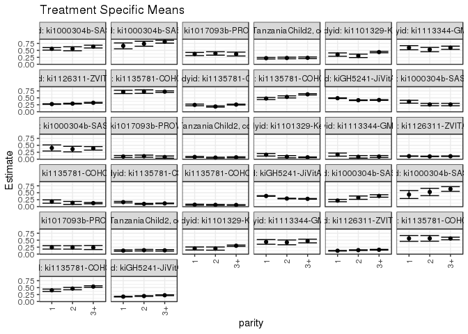

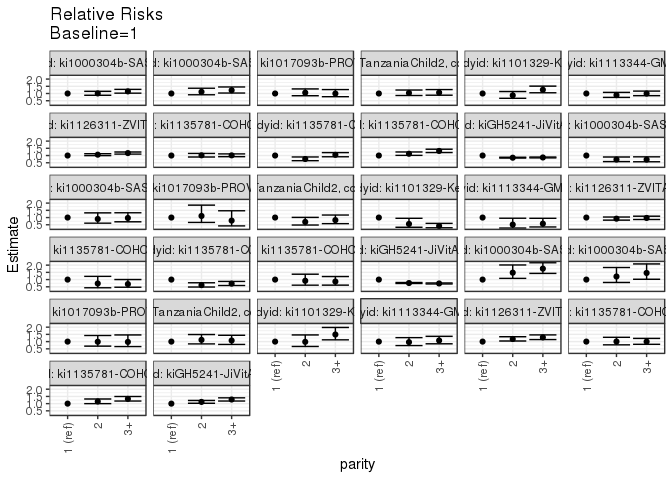

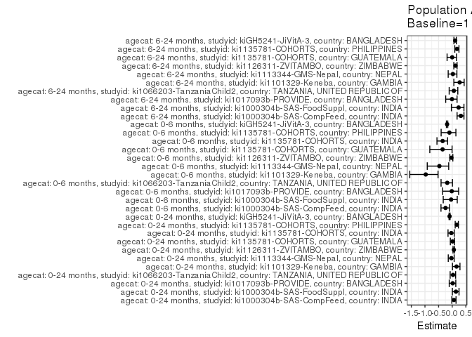

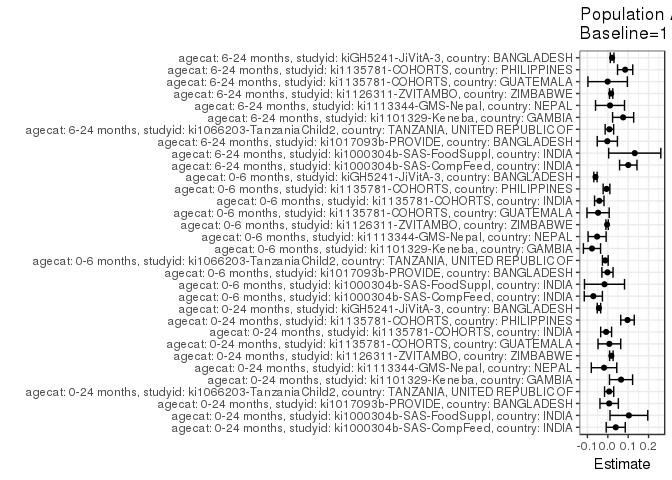

## Results Table

### Parameter: TSM

| agecat | studyid | country | intervention_level | baseline_level | estimate | ci_lower | ci_upper |
| --- | --- | --- | --- | --- | --- | --- | --- |
| 0-24 months | ki1000304b-SAS-CompFeed | INDIA | 1 | NA | 0.5553097 | 0.5090848 | 0.6015346 |
| 0-24 months | ki1000304b-SAS-CompFeed | INDIA | 2 | NA | 0.5583333 | 0.4868382 | 0.6298284 |
| 0-24 months | ki1000304b-SAS-CompFeed | INDIA | 3+ | NA | 0.6366158 | 0.5866361 | 0.6865956 |
| 0-24 months | ki1000304b-SAS-FoodSuppl | INDIA | 1 | NA | 0.6623377 | 0.5565752 | 0.7681001 |
| 0-24 months | ki1000304b-SAS-FoodSuppl | INDIA | 2 | NA | 0.7391304 | 0.6492895 | 0.8289713 |
| 0-24 months | ki1000304b-SAS-FoodSuppl | INDIA | 3+ | NA | 0.8114035 | 0.7605626 | 0.8622444 |
| 0-24 months | ki1017093b-PROVIDE | BANGLADESH | 1 | NA | 0.3690037 | 0.3115123 | 0.4264951 |
| 0-24 months | ki1017093b-PROVIDE | BANGLADESH | 2 | NA | 0.3893443 | 0.3281193 | 0.4505693 |
| 0-24 months | ki1017093b-PROVIDE | BANGLADESH | 3+ | NA | 0.3675676 | 0.2980414 | 0.4370937 |
| 0-24 months | ki1066203-TanzaniaChild2 | TANZANIA, UNITED REPUBLIC OF | 1 | NA | 0.2185273 | 0.1906087 | 0.2464459 |
| 0-24 months | ki1066203-TanzaniaChild2 | TANZANIA, UNITED REPUBLIC OF | 2 | NA | 0.2260982 | 0.1966227 | 0.2555737 |
| 0-24 months | ki1066203-TanzaniaChild2 | TANZANIA, UNITED REPUBLIC OF | 3+ | NA | 0.2315930 | 0.2013352 | 0.2618509 |
| 0-24 months | ki1101329-Keneba | GAMBIA | 1 | NA | 0.3485477 | 0.2883720 | 0.4087234 |
| 0-24 months | ki1101329-Keneba | GAMBIA | 2 | NA | 0.3037383 | 0.2421091 | 0.3653675 |
| 0-24 months | ki1101329-Keneba | GAMBIA | 3+ | NA | 0.4390879 | 0.4142551 | 0.4639208 |
| 0-24 months | ki1113344-GMS-Nepal | NEPAL | 1 | NA | 0.5964912 | 0.5228977 | 0.6700847 |
| 0-24 months | ki1113344-GMS-Nepal | NEPAL | 2 | NA | 0.5290323 | 0.4503857 | 0.6076789 |
| 0-24 months | ki1113344-GMS-Nepal | NEPAL | 3+ | NA | 0.5942029 | 0.5362231 | 0.6521827 |
| 0-24 months | ki1126311-ZVITAMBO | ZIMBABWE | 1 | NA | 0.2750494 | 0.2638137 | 0.2862851 |
| 0-24 months | ki1126311-ZVITAMBO | ZIMBABWE | 2 | NA | 0.2915480 | 0.2778224 | 0.3052735 |
| 0-24 months | ki1126311-ZVITAMBO | ZIMBABWE | 3+ | NA | 0.3217300 | 0.3068611 | 0.3365988 |
| 0-24 months | ki1135781-COHORTS | GUATEMALA | 1 | NA | 0.7136150 | 0.6528820 | 0.7743481 |
| 0-24 months | ki1135781-COHORTS | GUATEMALA | 2 | NA | 0.7239583 | 0.6607024 | 0.7872143 |
| 0-24 months | ki1135781-COHORTS | GUATEMALA | 3+ | NA | 0.7225131 | 0.6941045 | 0.7509217 |
| 0-24 months | ki1135781-COHORTS | INDIA | 1 | NA | 0.2450739 | 0.2154857 | 0.2746620 |
| 0-24 months | ki1135781-COHORTS | INDIA | 2 | NA | 0.1864979 | 0.1643184 | 0.2086774 |
| 0-24 months | ki1135781-COHORTS | INDIA | 3+ | NA | 0.2571212 | 0.2404257 | 0.2738166 |
| 0-24 months | ki1135781-COHORTS | PHILIPPINES | 1 | NA | 0.4749263 | 0.4373315 | 0.5125210 |
| 0-24 months | ki1135781-COHORTS | PHILIPPINES | 2 | NA | 0.5333333 | 0.4961030 | 0.5705637 |
| 0-24 months | ki1135781-COHORTS | PHILIPPINES | 3+ | NA | 0.6260355 | 0.6029632 | 0.6491078 |

[output cut: 66 more lines]

### Parameter: E(Y)

| agecat | studyid | country | intervention_level | baseline_level | estimate | ci_lower | ci_upper |
| --- | --- | --- | --- | --- | --- | --- | --- |
| 0-24 months | ki1000304b-SAS-CompFeed | INDIA | NA | NA | 0.5942596 | 0.5539147 | 0.6346046 |
| 0-24 months | ki1000304b-SAS-FoodSuppl | INDIA | NA | NA | 0.7657431 | 0.7240285 | 0.8074577 |
| 0-24 months | ki1017093b-PROVIDE | BANGLADESH | NA | NA | 0.3757143 | 0.3398113 | 0.4116172 |
| 0-24 months | ki1066203-TanzaniaChild2 | TANZANIA, UNITED REPUBLIC OF | NA | NA | 0.2251375 | 0.2082936 | 0.2419815 |
| 0-24 months | ki1101329-Keneba | GAMBIA | NA | NA | 0.4135678 | 0.3919251 | 0.4352106 |
| 0-24 months | ki1113344-GMS-Nepal | NEPAL | NA | NA | 0.5780731 | 0.5385891 | 0.6175571 |
| 0-24 months | ki1126311-ZVITAMBO | ZIMBABWE | NA | NA | 0.2925668 | 0.2850499 | 0.3000837 |
| 0-24 months | ki1135781-COHORTS | GUATEMALA | NA | NA | 0.7213235 | 0.6974864 | 0.7451606 |
| 0-24 months | ki1135781-COHORTS | INDIA | NA | NA | 0.2369330 | 0.2246841 | 0.2491820 |
| 0-24 months | ki1135781-COHORTS | PHILIPPINES | NA | NA | 0.5716154 | 0.5540738 | 0.5891570 |
| 0-24 months | kiGH5241-JiVitA-3 | BANGLADESH | NA | NA | 0.4438279 | 0.4363078 | 0.4513480 |
| 0-6 months | ki1000304b-SAS-CompFeed | INDIA | NA | NA | 0.2882353 | 0.2618269 | 0.3146436 |
| 0-6 months | ki1000304b-SAS-FoodSuppl | INDIA | NA | NA | 0.3863636 | 0.3383457 | 0.4343815 |
| 0-6 months | ki1017093b-PROVIDE | BANGLADESH | NA | NA | 0.0942857 | 0.0726222 | 0.1159492 |
| 0-6 months | ki1066203-TanzaniaChild2 | TANZANIA, UNITED REPUBLIC OF | NA | NA | 0.0672873 | 0.0571844 | 0.0773903 |
| 0-6 months | ki1101329-Keneba | GAMBIA | NA | NA | 0.0798705 | 0.0675239 | 0.0922170 |
| 0-6 months | ki1113344-GMS-Nepal | NEPAL | NA | NA | 0.1112957 | 0.0861520 | 0.1364394 |
| 0-6 months | ki1126311-ZVITAMBO | ZIMBABWE | NA | NA | 0.1052669 | 0.1001921 | 0.1103417 |
| 0-6 months | ki1135781-COHORTS | GUATEMALA | NA | NA | 0.1347388 | 0.1144687 | 0.1550088 |
| 0-6 months | ki1135781-COHORTS | INDIA | NA | NA | 0.1189358 | 0.1094482 | 0.1284235 |
| 0-6 months | ki1135781-COHORTS | PHILIPPINES | NA | NA | 0.0614781 | 0.0529631 | 0.0699931 |
| 0-6 months | kiGH5241-JiVitA-3 | BANGLADESH | NA | NA | 0.3219377 | 0.3151813 | 0.3286942 |
| 6-24 months | ki1000304b-SAS-CompFeed | INDIA | NA | NA | 0.3184647 | 0.2882909 | 0.3486385 |
| 6-24 months | ki1000304b-SAS-FoodSuppl | INDIA | NA | NA | 0.5669643 | 0.5019310 | 0.6319975 |
| 6-24 months | ki1017093b-PROVIDE | BANGLADESH | NA | NA | 0.2394366 | 0.2018814 | 0.2769918 |
| 6-24 months | ki1066203-TanzaniaChild2 | TANZANIA, UNITED REPUBLIC OF | NA | NA | 0.1322722 | 0.1167119 | 0.1478326 |
| 6-24 months | ki1101329-Keneba | GAMBIA | NA | NA | 0.2761283 | 0.2547687 | 0.2974878 |
| 6-24 months | ki1113344-GMS-Nepal | NEPAL | NA | NA | 0.4479167 | 0.4033837 | 0.4924496 |
| 6-24 months | ki1126311-ZVITAMBO | ZIMBABWE | NA | NA | 0.1358952 | 0.1289363 | 0.1428542 |
| 6-24 months | ki1135781-COHORTS | GUATEMALA | NA | NA | 0.5625000 | 0.5235458 | 0.6014542 |
| 6-24 months | ki1135781-COHORTS | PHILIPPINES | NA | NA | 0.4901079 | 0.4693271 | 0.5108888 |
| 6-24 months | kiGH5241-JiVitA-3 | BANGLADESH | NA | NA | 0.1970221 | 0.1889626 | 0.2050817 |

### Parameter: RR

| agecat | studyid | country | intervention_level | baseline_level | estimate | ci_lower | ci_upper |
| --- | --- | --- | --- | --- | --- | --- | --- |
| 0-24 months | ki1000304b-SAS-CompFeed | INDIA | 1 | 1 | 1.0000000 | 1.0000000 | 1.0000000 |
| 0-24 months | ki1000304b-SAS-CompFeed | INDIA | 2 | 1 | 1.0054449 | 0.8781547 | 1.1511860 |
| 0-24 months | ki1000304b-SAS-CompFeed | INDIA | 3+ | 1 | 1.1464157 | 1.0220096 | 1.2859655 |
| 0-24 months | ki1000304b-SAS-FoodSuppl | INDIA | 1 | 1 | 1.0000000 | 1.0000000 | 1.0000000 |
| 0-24 months | ki1000304b-SAS-FoodSuppl | INDIA | 2 | 1 | 1.1159420 | 0.9130357 | 1.3639407 |
| 0-24 months | ki1000304b-SAS-FoodSuppl | INDIA | 3+ | 1 | 1.2250602 | 1.0319560 | 1.4542989 |
| 0-24 months | ki1017093b-PROVIDE | BANGLADESH | 1 | 1 | 1.0000000 | 1.0000000 | 1.0000000 |
| 0-24 months | ki1017093b-PROVIDE | BANGLADESH | 2 | 1 | 1.0551230 | 0.8456015 | 1.3165592 |
| 0-24 months | ki1017093b-PROVIDE | BANGLADESH | 3+ | 1 | 0.9961081 | 0.7796143 | 1.2727208 |
| 0-24 months | ki1066203-TanzaniaChild2 | TANZANIA, UNITED REPUBLIC OF | 1 | 1 | 1.0000000 | 1.0000000 | 1.0000000 |
| 0-24 months | ki1066203-TanzaniaChild2 | TANZANIA, UNITED REPUBLIC OF | 2 | 1 | 1.0346450 | 0.8620241 | 1.2418333 |
| 0-24 months | ki1066203-TanzaniaChild2 | TANZANIA, UNITED REPUBLIC OF | 3+ | 1 | 1.0597899 | 0.8827939 | 1.2722727 |
| 0-24 months | ki1101329-Keneba | GAMBIA | 1 | 1 | 1.0000000 | 1.0000000 | 1.0000000 |
| 0-24 months | ki1101329-Keneba | GAMBIA | 2 | 1 | 0.8714397 | 0.6676292 | 1.1374684 |
| 0-24 months | ki1101329-Keneba | GAMBIA | 3+ | 1 | 1.2597642 | 1.0504834 | 1.5107387 |
| 0-24 months | ki1113344-GMS-Nepal | NEPAL | 1 | 1 | 1.0000000 | 1.0000000 | 1.0000000 |
| 0-24 months | ki1113344-GMS-Nepal | NEPAL | 2 | 1 | 0.8869070 | 0.7311004 | 1.0759180 |
| 0-24 months | ki1113344-GMS-Nepal | NEPAL | 3+ | 1 | 0.9961637 | 0.8511706 | 1.1658557 |
| 0-24 months | ki1126311-ZVITAMBO | ZIMBABWE | 1 | 1 | 1.0000000 | 1.0000000 | 1.0000000 |
| 0-24 months | ki1126311-ZVITAMBO | ZIMBABWE | 2 | 1 | 1.0599838 | 0.9959317 | 1.1281554 |
| 0-24 months | ki1126311-ZVITAMBO | ZIMBABWE | 3+ | 1 | 1.1697168 | 1.0997476 | 1.2441377 |
| 0-24 months | ki1135781-COHORTS | GUATEMALA | 1 | 1 | 1.0000000 | 1.0000000 | 1.0000000 |
| 0-24 months | ki1135781-COHORTS | GUATEMALA | 2 | 1 | 1.0144942 | 0.8980019 | 1.1460984 |
| 0-24 months | ki1135781-COHORTS | GUATEMALA | 3+ | 1 | 1.0124690 | 0.9218635 | 1.1119797 |
| 0-24 months | ki1135781-COHORTS | INDIA | 1 | 1 | 1.0000000 | 1.0000000 | 1.0000000 |
| 0-24 months | ki1135781-COHORTS | INDIA | 2 | 1 | 0.7609864 | 0.6423587 | 0.9015216 |
| 0-24 months | ki1135781-COHORTS | INDIA | 3+ | 1 | 1.0491577 | 0.9147565 | 1.2033058 |
| 0-24 months | ki1135781-COHORTS | PHILIPPINES | 1 | 1 | 1.0000000 | 1.0000000 | 1.0000000 |
| 0-24 months | ki1135781-COHORTS | PHILIPPINES | 2 | 1 | 1.1229814 | 1.0104995 | 1.2479840 |
| 0-24 months | ki1135781-COHORTS | PHILIPPINES | 3+ | 1 | 1.3181741 | 1.2079558 | 1.4384492 |

[output cut: 66 more lines]

### Parameter: PAR

| agecat | studyid | country | intervention_level | baseline_level | estimate | ci_lower | ci_upper |
| --- | --- | --- | --- | --- | --- | --- | --- |
| 0-24 months | ki1000304b-SAS-CompFeed | INDIA | 1 | NA | 0.0389499 | -0.0078059 | 0.0857057 |
| 0-24 months | ki1000304b-SAS-FoodSuppl | INDIA | 1 | NA | 0.1034054 | 0.0107406 | 0.1960702 |
| 0-24 months | ki1017093b-PROVIDE | BANGLADESH | 1 | NA | 0.0067106 | -0.0384011 | 0.0518223 |
| 0-24 months | ki1066203-TanzaniaChild2 | TANZANIA, UNITED REPUBLIC OF | 1 | NA | 0.0066102 | -0.0159218 | 0.0291422 |
| 0-24 months | ki1101329-Keneba | GAMBIA | 1 | NA | 0.0650201 | 0.0083416 | 0.1216986 |
| 0-24 months | ki1113344-GMS-Nepal | NEPAL | 1 | NA | -0.0184181 | -0.0808531 | 0.0440168 |
| 0-24 months | ki1126311-ZVITAMBO | ZIMBABWE | 1 | NA | 0.0175174 | 0.0089225 | 0.0261123 |
| 0-24 months | ki1135781-COHORTS | GUATEMALA | 1 | NA | 0.0077085 | -0.0479812 | 0.0633982 |
| 0-24 months | ki1135781-COHORTS | INDIA | 1 | NA | -0.0081408 | -0.0349443 | 0.0186626 |
| 0-24 months | ki1135781-COHORTS | PHILIPPINES | 1 | NA | 0.0966892 | 0.0636082 | 0.1297701 |
| 0-24 months | kiGH5241-JiVitA-3 | BANGLADESH | 1 | NA | -0.0433642 | -0.0517410 | -0.0349874 |
| 0-6 months | ki1000304b-SAS-CompFeed | INDIA | 1 | NA | -0.0709665 | -0.1154746 | -0.0264584 |
| 0-6 months | ki1000304b-SAS-FoodSuppl | INDIA | 1 | NA | -0.0162338 | -0.1145037 | 0.0820362 |
| 0-6 months | ki1017093b-PROVIDE | BANGLADESH | 1 | NA | -0.0016552 | -0.0289905 | 0.0256800 |
| 0-6 months | ki1066203-TanzaniaChild2 | TANZANIA, UNITED REPUBLIC OF | 1 | NA | -0.0122851 | -0.0263608 | 0.0017906 |
| 0-6 months | ki1101329-Keneba | GAMBIA | 1 | NA | -0.0775763 | -0.1196689 | -0.0354837 |
| 0-6 months | ki1113344-GMS-Nepal | NEPAL | 1 | NA | -0.0524470 | -0.0967524 | -0.0081416 |
| 0-6 months | ki1126311-ZVITAMBO | ZIMBABWE | 1 | NA | -0.0033319 | -0.0091794 | 0.0025157 |
| 0-6 months | ki1135781-COHORTS | GUATEMALA | 1 | NA | -0.0476512 | -0.1021115 | 0.0068091 |
| 0-6 months | ki1135781-COHORTS | INDIA | 1 | NA | -0.0418485 | -0.0649984 | -0.0186986 |
| 0-6 months | ki1135781-COHORTS | PHILIPPINES | 1 | NA | -0.0063685 | -0.0228611 | 0.0101241 |
| 0-6 months | kiGH5241-JiVitA-3 | BANGLADESH | 1 | NA | -0.0604498 | -0.0684616 | -0.0524381 |
| 6-24 months | ki1000304b-SAS-CompFeed | INDIA | 1 | NA | 0.1004717 | 0.0578051 | 0.1431382 |
| 6-24 months | ki1000304b-SAS-FoodSuppl | INDIA | 1 | NA | 0.1321817 | 0.0042088 | 0.2601545 |
| 6-24 months | ki1017093b-PROVIDE | BANGLADESH | 1 | NA | -0.0023216 | -0.0517977 | 0.0471545 |
| 6-24 months | ki1066203-TanzaniaChild2 | TANZANIA, UNITED REPUBLIC OF | 1 | NA | 0.0078554 | -0.0129698 | 0.0286806 |
| 6-24 months | ki1101329-Keneba | GAMBIA | 1 | NA | 0.0751713 | 0.0234381 | 0.1269046 |
| 6-24 months | ki1113344-GMS-Nepal | NEPAL | 1 | NA | 0.0108796 | -0.0602014 | 0.0819607 |
| 6-24 months | ki1126311-ZVITAMBO | ZIMBABWE | 1 | NA | 0.0162854 | 0.0081975 | 0.0243733 |
| 6-24 months | ki1135781-COHORTS | GUATEMALA | 1 | NA | -0.0007184 | -0.0974827 | 0.0960459 |
| 6-24 months | ki1135781-COHORTS | PHILIPPINES | 1 | NA | 0.0850692 | 0.0477351 | 0.1224032 |
| 6-24 months | kiGH5241-JiVitA-3 | BANGLADESH | 1 | NA | 0.0212314 | 0.0123492 | 0.0301135 |

### Parameter: PAF

| agecat | studyid | country | intervention_level | baseline_level | estimate | ci_lower | ci_upper |
| --- | --- | --- | --- | --- | --- | --- | --- |
| 0-24 months | ki1000304b-SAS-CompFeed | INDIA | 1 | NA | 0.0655436 | -0.0145056 | 0.1392765 |
| 0-24 months | ki1000304b-SAS-FoodSuppl | INDIA | 1 | NA | 0.1350393 | 0.0039595 | 0.2488689 |
| 0-24 months | ki1017093b-PROVIDE | BANGLADESH | 1 | NA | 0.0178609 | -0.1098586 | 0.1308828 |
| 0-24 months | ki1066203-TanzaniaChild2 | TANZANIA, UNITED REPUBLIC OF | 1 | NA | 0.0293608 | -0.0760502 | 0.1244456 |
| 0-24 months | ki1101329-Keneba | GAMBIA | 1 | NA | 0.1572175 | 0.0083429 | 0.2837421 |
| 0-24 months | ki1113344-GMS-Nepal | NEPAL | 1 | NA | -0.0318613 | -0.1457660 | 0.0707198 |
| 0-24 months | ki1126311-ZVITAMBO | ZIMBABWE | 1 | NA | 0.0598747 | 0.0300426 | 0.0887894 |
| 0-24 months | ki1135781-COHORTS | GUATEMALA | 1 | NA | 0.0106866 | -0.0696143 | 0.0849589 |
| 0-24 months | ki1135781-COHORTS | INDIA | 1 | NA | -0.0343593 | -0.1538983 | 0.0727960 |
| 0-24 months | ki1135781-COHORTS | PHILIPPINES | 1 | NA | 0.1691508 | 0.1089117 | 0.2253176 |
| 0-24 months | kiGH5241-JiVitA-3 | BANGLADESH | 1 | NA | -0.0977049 | -0.1167202 | -0.0790134 |
| 0-6 months | ki1000304b-SAS-CompFeed | INDIA | 1 | NA | -0.2462102 | -0.4122309 | -0.0997068 |
| 0-6 months | ki1000304b-SAS-FoodSuppl | INDIA | 1 | NA | -0.0420168 | -0.3301131 | 0.1836792 |
| 0-6 months | ki1017093b-PROVIDE | BANGLADESH | 1 | NA | -0.0175556 | -0.3529663 | 0.2347042 |
| 0-6 months | ki1066203-TanzaniaChild2 | TANZANIA, UNITED REPUBLIC OF | 1 | NA | -0.1825767 | -0.4096247 | 0.0079008 |
| 0-6 months | ki1101329-Keneba | GAMBIA | 1 | NA | -0.9712766 | -1.5568906 | -0.5197879 |
| 0-6 months | ki1113344-GMS-Nepal | NEPAL | 1 | NA | -0.4712403 | -0.9165067 | -0.1294236 |
| 0-6 months | ki1126311-ZVITAMBO | ZIMBABWE | 1 | NA | -0.0316517 | -0.0887073 | 0.0224139 |
| 0-6 months | ki1135781-COHORTS | GUATEMALA | 1 | NA | -0.3536559 | -0.8219396 | -0.0057328 |
| 0-6 months | ki1135781-COHORTS | INDIA | 1 | NA | -0.3518576 | -0.5597210 | -0.1716961 |
| 0-6 months | ki1135781-COHORTS | PHILIPPINES | 1 | NA | -0.1035900 | -0.4068563 | 0.1343032 |
| 0-6 months | kiGH5241-JiVitA-3 | BANGLADESH | 1 | NA | -0.1877688 | -0.2128731 | -0.1631840 |
| 6-24 months | ki1000304b-SAS-CompFeed | INDIA | 1 | NA | 0.3154875 | 0.1778173 | 0.4301056 |
| 6-24 months | ki1000304b-SAS-FoodSuppl | INDIA | 1 | NA | 0.2331393 | -0.0314468 | 0.4298540 |
| 6-24 months | ki1017093b-PROVIDE | BANGLADESH | 1 | NA | -0.0096962 | -0.2389925 | 0.1771650 |
| 6-24 months | ki1066203-TanzaniaChild2 | TANZANIA, UNITED REPUBLIC OF | 1 | NA | 0.0593884 | -0.1118665 | 0.2042658 |
| 6-24 months | ki1101329-Keneba | GAMBIA | 1 | NA | 0.2722334 | 0.0592375 | 0.4370054 |
| 6-24 months | ki1113344-GMS-Nepal | NEPAL | 1 | NA | 0.0242894 | -0.1480500 | 0.1707581 |
| 6-24 months | ki1126311-ZVITAMBO | ZIMBABWE | 1 | NA | 0.1198377 | 0.0585091 | 0.1771714 |
| 6-24 months | ki1135781-COHORTS | GUATEMALA | 1 | NA | -0.0012771 | -0.1889640 | 0.1567819 |
| 6-24 months | ki1135781-COHORTS | PHILIPPINES | 1 | NA | 0.1735723 | 0.0935469 | 0.2465327 |
| 6-24 months | kiGH5241-JiVitA-3 | BANGLADESH | 1 | NA | 0.1077613 | 0.0618351 | 0.1514392 |